# Risk Factor Analysis

## Outcome Variable

**Outcome Variable:** wasted

## Predictor Variables

**Intervention Variable:** mage

**Adjustment Set:**

- arm
- meducyrs
- feducyrs
- hhwealth_quart
- W_mhtcm
- W_nrooms
- impfloor
- impsan
- delta_meducyrs
- delta_feducyrs
- delta_hhwealth_quart
- delta_W_mhtcm
- delta_W_nrooms
- delta_impfloor
- delta_impsan

## Stratifying Variables

The analysis was stratified on these variable(s):

- agecat
- studyid
- country

## Data Summary

| agecat | studyid | country | mage | wasted | n_cell | n |
| --- | --- | --- | --- | --- | --- | --- |
| Birth | ki0047075b-MAL-ED | BANGLADESH | <25 | 0 | 91 | 241 |
| Birth | ki0047075b-MAL-ED | BANGLADESH | <25 | 1 | 18 | 241 |
| Birth | ki0047075b-MAL-ED | BANGLADESH | [25-30) | 0 | 76 | 241 |
| Birth | ki0047075b-MAL-ED | BANGLADESH | [25-30) | 1 | 13 | 241 |
| Birth | ki0047075b-MAL-ED | BANGLADESH | >=30 | 0 | 34 | 241 |
| Birth | ki0047075b-MAL-ED | BANGLADESH | >=30 | 1 | 9 | 241 |
| Birth | ki0047075b-MAL-ED | BRAZIL | <25 | 0 | 93 | 183 |
| Birth | ki0047075b-MAL-ED | BRAZIL | <25 | 1 | 1 | 183 |
| Birth | ki0047075b-MAL-ED | BRAZIL | [25-30) | 0 | 47 | 183 |
| Birth | ki0047075b-MAL-ED | BRAZIL | [25-30) | 1 | 3 | 183 |
| Birth | ki0047075b-MAL-ED | BRAZIL | >=30 | 0 | 37 | 183 |
| Birth | ki0047075b-MAL-ED | BRAZIL | >=30 | 1 | 2 | 183 |
| Birth | ki0047075b-MAL-ED | INDIA | <25 | 0 | 100 | 202 |
| Birth | ki0047075b-MAL-ED | INDIA | <25 | 1 | 20 | 202 |
| Birth | ki0047075b-MAL-ED | INDIA | [25-30) | 0 | 56 | 202 |
| Birth | ki0047075b-MAL-ED | INDIA | [25-30) | 1 | 11 | 202 |
| Birth | ki0047075b-MAL-ED | INDIA | >=30 | 0 | 13 | 202 |
| Birth | ki0047075b-MAL-ED | INDIA | >=30 | 1 | 2 | 202 |
| Birth | ki0047075b-MAL-ED | NEPAL | <25 | 0 | 35 | 168 |
| Birth | ki0047075b-MAL-ED | NEPAL | <25 | 1 | 8 | 168 |
| Birth | ki0047075b-MAL-ED | NEPAL | [25-30) | 0 | 81 | 168 |
| Birth | ki0047075b-MAL-ED | NEPAL | [25-30) | 1 | 9 | 168 |
| Birth | ki0047075b-MAL-ED | NEPAL | >=30 | 0 | 32 | 168 |
| Birth | ki0047075b-MAL-ED | NEPAL | >=30 | 1 | 3 | 168 |
| Birth | ki0047075b-MAL-ED | PERU | <25 | 0 | 152 | 279 |
| Birth | ki0047075b-MAL-ED | PERU | <25 | 1 | 3 | 279 |
| Birth | ki0047075b-MAL-ED | PERU | [25-30) | 0 | 58 | 279 |
| Birth | ki0047075b-MAL-ED | PERU | [25-30) | 1 | 2 | 279 |
| Birth | ki0047075b-MAL-ED | PERU | >=30 | 0 | 63 | 279 |
| Birth | ki0047075b-MAL-ED | PERU | >=30 | 1 | 1 | 279 |

[output cut: 378 more lines]

The following strata were considered:

- agecat: 24 months, studyid: ki0047075b-MAL-ED, country: BANGLADESH
- agecat: 24 months, studyid: ki0047075b-MAL-ED, country: BRAZIL
- agecat: 24 months, studyid: ki0047075b-MAL-ED, country: INDIA
- agecat: 24 months, studyid: ki0047075b-MAL-ED, country: NEPAL
- agecat: 24 months, studyid: ki0047075b-MAL-ED, country: PERU
- agecat: 24 months, studyid: ki0047075b-MAL-ED, country: SOUTH AFRICA
- agecat: 24 months, studyid: ki0047075b-MAL-ED, country: TANZANIA, UNITED REPUBLIC OF
- agecat: 24 months, studyid: ki1000108-CMC-V-BCS-2002, country: INDIA
- agecat: 24 months, studyid: ki1000108-IRC, country: INDIA
- agecat: 24 months, studyid: ki1017093-NIH-Birth, country: BANGLADESH
- agecat: 24 months, studyid: ki1017093b-PROVIDE, country: BANGLADESH
- agecat: 24 months, studyid: ki1017093c-NIH-Crypto, country: BANGLADESH
- agecat: 24 months, studyid: ki1066203-TanzaniaChild2, country: TANZANIA, UNITED REPUBLIC OF
- agecat: 24 months, studyid: ki1101329-Keneba, country: GAMBIA
- agecat: 24 months, studyid: ki1113344-GMS-Nepal, country: NEPAL
- agecat: 24 months, studyid: ki1119695-PROBIT, country: BELARUS
- agecat: 24 months, studyid: ki1126311-ZVITAMBO, country: ZIMBABWE
- agecat: 24 months, studyid: ki1135781-COHORTS, country: GUATEMALA
- agecat: 24 months, studyid: ki1135781-COHORTS, country: INDIA
- agecat: 24 months, studyid: ki1135781-COHORTS, country: PHILIPPINES
- agecat: 24 months, studyid: ki1148112-LCNI-5, country: MALAWI
- agecat: 24 months, studyid: kiGH5241-JiVitA-3, country: BANGLADESH
- agecat: 6 months, studyid: ki0047075b-MAL-ED, country: BANGLADESH
- agecat: 6 months, studyid: ki0047075b-MAL-ED, country: BRAZIL
- agecat: 6 months, studyid: ki0047075b-MAL-ED, country: INDIA
- agecat: 6 months, studyid: ki0047075b-MAL-ED, country: NEPAL
- agecat: 6 months, studyid: ki0047075b-MAL-ED, country: PERU
- agecat: 6 months, studyid: ki0047075b-MAL-ED, country: SOUTH AFRICA
- agecat: 6 months, studyid: ki0047075b-MAL-ED, country: TANZANIA, UNITED REPUBLIC OF
- agecat: 6 months, studyid: ki1000108-CMC-V-BCS-2002, country: INDIA
- agecat: 6 months, studyid: ki1000108-IRC, country: INDIA
- agecat: 6 months, studyid: ki1000109-EE, country: PAKISTAN
- agecat: 6 months, studyid: ki1000304b-SAS-CompFeed, country: INDIA
- agecat: 6 months, studyid: ki1000304b-SAS-FoodSuppl, country: INDIA
- agecat: 6 months, studyid: ki1017093-NIH-Birth, country: BANGLADESH
- agecat: 6 months, studyid: ki1017093b-PROVIDE, country: BANGLADESH
- agecat: 6 months, studyid: ki1017093c-NIH-Crypto, country: BANGLADESH
- agecat: 6 months, studyid: ki1066203-TanzaniaChild2, country: TANZANIA, UNITED REPUBLIC OF
- agecat: 6 months, studyid: ki1101329-Keneba, country: GAMBIA
- agecat: 6 months, studyid: ki1112895-Guatemala BSC, country: GUATEMALA
- agecat: 6 months, studyid: ki1113344-GMS-Nepal, country: NEPAL
- agecat: 6 months, studyid: ki1119695-PROBIT, country: BELARUS
- agecat: 6 months, studyid: ki1126311-ZVITAMBO, country: ZIMBABWE
- agecat: 6 months, studyid: ki1135781-COHORTS, country: GUATEMALA
- agecat: 6 months, studyid: ki1135781-COHORTS, country: INDIA
- agecat: 6 months, studyid: ki1135781-COHORTS, country: PHILIPPINES
- agecat: 6 months, studyid: ki1148112-LCNI-5, country: MALAWI
- agecat: 6 months, studyid: kiGH5241-JiVitA-3, country: BANGLADESH
- agecat: Birth, studyid: ki0047075b-MAL-ED, country: BANGLADESH
- agecat: Birth, studyid: ki0047075b-MAL-ED, country: BRAZIL
- agecat: Birth, studyid: ki0047075b-MAL-ED, country: INDIA
- agecat: Birth, studyid: ki0047075b-MAL-ED, country: NEPAL
- agecat: Birth, studyid: ki0047075b-MAL-ED, country: PERU
- agecat: Birth, studyid: ki0047075b-MAL-ED, country: SOUTH AFRICA
- agecat: Birth, studyid: ki0047075b-MAL-ED, country: TANZANIA, UNITED REPUBLIC OF
- agecat: Birth, studyid: ki1000108-CMC-V-BCS-2002, country: INDIA
- agecat: Birth, studyid: ki1000108-IRC, country: INDIA
- agecat: Birth, studyid: ki1000109-EE, country: PAKISTAN
- agecat: Birth, studyid: ki1000304b-SAS-CompFeed, country: INDIA
- agecat: Birth, studyid: ki1017093-NIH-Birth, country: BANGLADESH
- agecat: Birth, studyid: ki1017093c-NIH-Crypto, country: BANGLADESH
- agecat: Birth, studyid: ki1101329-Keneba, country: GAMBIA
- agecat: Birth, studyid: ki1119695-PROBIT, country: BELARUS
- agecat: Birth, studyid: ki1126311-ZVITAMBO, country: ZIMBABWE
- agecat: Birth, studyid: ki1135781-COHORTS, country: GUATEMALA
- agecat: Birth, studyid: ki1135781-COHORTS, country: INDIA
- agecat: Birth, studyid: ki1135781-COHORTS, country: PHILIPPINES
- agecat: Birth, studyid: kiGH5241-JiVitA-3, country: BANGLADESH

### Dropped Strata

Some strata were dropped due to rare outcomes:

- agecat: Birth, studyid: ki0047075b-MAL-ED, country: BRAZIL
- agecat: Birth, studyid: ki0047075b-MAL-ED, country: INDIA
- agecat: Birth, studyid: ki0047075b-MAL-ED, country: NEPAL
- agecat: Birth, studyid: ki0047075b-MAL-ED, country: PERU
- agecat: Birth, studyid: ki0047075b-MAL-ED, country: SOUTH AFRICA
- agecat: Birth, studyid: ki0047075b-MAL-ED, country: TANZANIA, UNITED REPUBLIC OF
- agecat: Birth, studyid: ki1000108-CMC-V-BCS-2002, country: INDIA
- agecat: Birth, studyid: ki1000109-EE, country: PAKISTAN
- agecat: Birth, studyid: ki1000304b-SAS-CompFeed, country: INDIA
- agecat: Birth, studyid: ki1017093-NIH-Birth, country: BANGLADESH
- agecat: Birth, studyid: ki1017093c-NIH-Crypto, country: BANGLADESH
- agecat: 6 months, studyid: ki0047075b-MAL-ED, country: BANGLADESH
- agecat: 6 months, studyid: ki0047075b-MAL-ED, country: BRAZIL
- agecat: 6 months, studyid: ki0047075b-MAL-ED, country: INDIA
- agecat: 6 months, studyid: ki0047075b-MAL-ED, country: NEPAL
- agecat: 6 months, studyid: ki0047075b-MAL-ED, country: PERU
- agecat: 6 months, studyid: ki0047075b-MAL-ED, country: SOUTH AFRICA
- agecat: 6 months, studyid: ki0047075b-MAL-ED, country: TANZANIA, UNITED REPUBLIC OF
- agecat: 6 months, studyid: ki1000108-CMC-V-BCS-2002, country: INDIA
- agecat: 6 months, studyid: ki1000109-EE, country: PAKISTAN
- agecat: 6 months, studyid: ki1017093c-NIH-Crypto, country: BANGLADESH
- agecat: 6 months, studyid: ki1112895-Guatemala BSC, country: GUATEMALA
- agecat: 6 months, studyid: ki1148112-LCNI-5, country: MALAWI
- agecat: 24 months, studyid: ki0047075b-MAL-ED, country: BANGLADESH
- agecat: 24 months, studyid: ki0047075b-MAL-ED, country: BRAZIL
- agecat: 24 months, studyid: ki0047075b-MAL-ED, country: INDIA
- agecat: 24 months, studyid: ki0047075b-MAL-ED, country: NEPAL
- agecat: 24 months, studyid: ki0047075b-MAL-ED, country: PERU
- agecat: 24 months, studyid: ki0047075b-MAL-ED, country: SOUTH AFRICA
- agecat: 24 months, studyid: ki0047075b-MAL-ED, country: TANZANIA, UNITED REPUBLIC OF
- agecat: 24 months, studyid: ki1000108-CMC-V-BCS-2002, country: INDIA
- agecat: 24 months, studyid: ki1066203-TanzaniaChild2, country: TANZANIA, UNITED REPUBLIC OF
- agecat: 24 months, studyid: ki1148112-LCNI-5, country: MALAWI

## Methods Detail

We’re interested in the causal parameters $E[Y_a]$ for all values of $a \in \mathcal{A}$. These parameters represent the mean outcome if, possibly contrary to fact, we intervened to set all units to have $A=a$. Under the randomization and positivity assumptions, these are identified by the statistical parameters $\psi_a=E_W[E_{Y|A,W}(Y|A=a,W)]$. In addition, we’re interested in the mean of $Y$, $E[Y]$ under no intervention (the observed mean). We will estimate these parameters by using SuperLearner to fit the relevant likelihood factors – $E_{Y|A,W}(Y|A=a,W)$ and $p(A=a|W)$, and then updating our likelihood fit using a joint TMLE.

For unadjusted analyses ($W=\{\}$), initial likelihoods were estimated using Lrnr_glm to estimate the simple $E(Y|A)$ and Lrnr_mean to estimate $p(A)$. For adjusted analyses, a small library containing Lrnr_glmnet, Lrnr_xgboost, and Lrnr_mean was used.

Having estimated these parameters, we will then use the delta method to estimate relative risks and attributable risks relative to a prespecified baseline level of $A$.

# Results Detail

## Results Plots

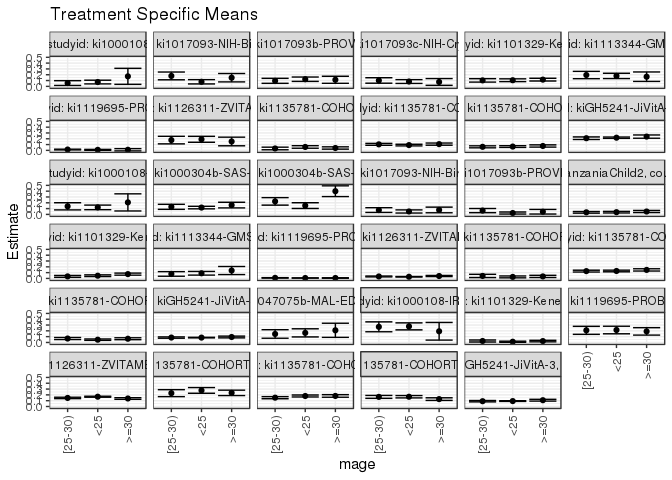

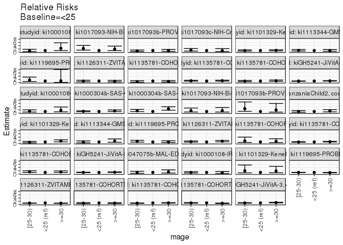

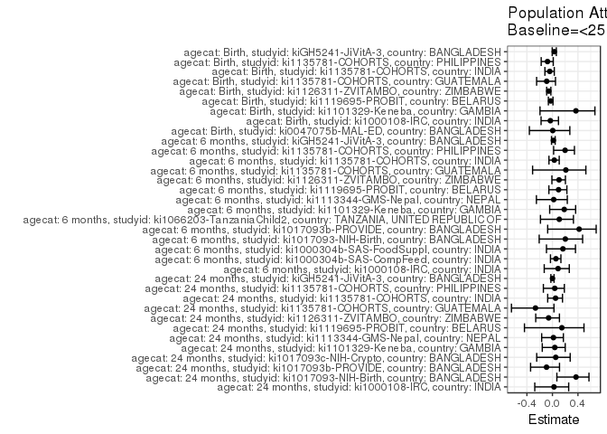

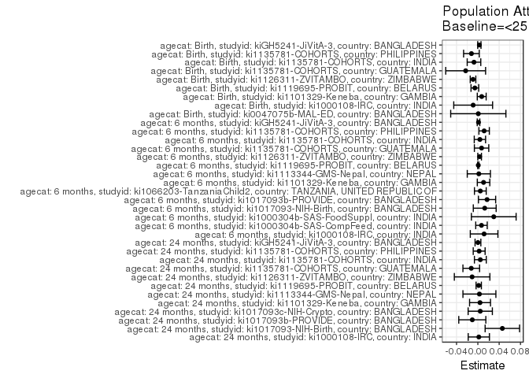

## Results Table

### Parameter: TSM

| agecat | studyid | country | intervention_level | baseline_level | estimate | ci_lower | ci_upper |
| --- | --- | --- | --- | --- | --- | --- | --- |
| Birth | ki0047075b-MAL-ED | BANGLADESH | <25 | NA | 0.1651376 | 0.0952873 | 0.2349879 |
| Birth | ki0047075b-MAL-ED | BANGLADESH | [25-30) | NA | 0.1460674 | 0.0725408 | 0.2195940 |
| Birth | ki0047075b-MAL-ED | BANGLADESH | >=30 | NA | 0.2093023 | 0.0874570 | 0.3311477 |
| Birth | ki1000108-IRC | INDIA | <25 | NA | 0.2769953 | 0.2168088 | 0.3371818 |
| Birth | ki1000108-IRC | INDIA | [25-30) | NA | 0.2692308 | 0.1838583 | 0.3546032 |
| Birth | ki1000108-IRC | INDIA | >=30 | NA | 0.1923077 | 0.0405968 | 0.3440186 |
| Birth | ki1101329-Keneba | GAMBIA | <25 | NA | 0.0124334 | 0.0032770 | 0.0215898 |
| Birth | ki1101329-Keneba | GAMBIA | [25-30) | NA | 0.0252366 | 0.0079649 | 0.0425083 |
| Birth | ki1101329-Keneba | GAMBIA | >=30 | NA | 0.0239411 | 0.0110790 | 0.0368031 |
| Birth | ki1119695-PROBIT | BELARUS | <25 | NA | 0.2145150 | 0.1493010 | 0.2797290 |
| Birth | ki1119695-PROBIT | BELARUS | [25-30) | NA | 0.2088089 | 0.1400328 | 0.2775850 |
| Birth | ki1119695-PROBIT | BELARUS | >=30 | NA | 0.1906612 | 0.1266269 | 0.2546956 |
| Birth | ki1126311-ZVITAMBO | ZIMBABWE | <25 | NA | 0.1683022 | 0.1598901 | 0.1767143 |
| Birth | ki1126311-ZVITAMBO | ZIMBABWE | [25-30) | NA | 0.1471101 | 0.1351036 | 0.1591166 |
| Birth | ki1126311-ZVITAMBO | ZIMBABWE | >=30 | NA | 0.1375759 | 0.1235902 | 0.1515615 |
| Birth | ki1135781-COHORTS | GUATEMALA | <25 | NA | 0.2768341 | 0.2277546 | 0.3259137 |
| Birth | ki1135781-COHORTS | GUATEMALA | [25-30) | NA | 0.2296493 | 0.1698422 | 0.2894563 |
| Birth | ki1135781-COHORTS | GUATEMALA | >=30 | NA | 0.2345271 | 0.1877662 | 0.2812880 |
| Birth | ki1135781-COHORTS | INDIA | <25 | NA | 0.1806902 | 0.1636802 | 0.1977001 |
| Birth | ki1135781-COHORTS | INDIA | [25-30) | NA | 0.1517763 | 0.1336898 | 0.1698628 |
| Birth | ki1135781-COHORTS | INDIA | >=30 | NA | 0.1814415 | 0.1594380 | 0.2034449 |
| Birth | ki1135781-COHORTS | PHILIPPINES | <25 | NA | 0.1675951 | 0.1474210 | 0.1877692 |
| Birth | ki1135781-COHORTS | PHILIPPINES | [25-30) | NA | 0.1652450 | 0.1405479 | 0.1899420 |
| Birth | ki1135781-COHORTS | PHILIPPINES | >=30 | NA | 0.1271274 | 0.1046220 | 0.1496327 |
| Birth | kiGH5241-JiVitA-3 | BANGLADESH | <25 | NA | 0.0930439 | 0.0871751 | 0.0989128 |
| Birth | kiGH5241-JiVitA-3 | BANGLADESH | [25-30) | NA | 0.0909181 | 0.0794017 | 0.1024344 |
| Birth | kiGH5241-JiVitA-3 | BANGLADESH | >=30 | NA | 0.1082727 | 0.0930653 | 0.1234801 |
| 6 months | ki1000108-IRC | INDIA | <25 | NA | 0.1206226 | 0.0807553 | 0.1604898 |
| 6 months | ki1000108-IRC | INDIA | [25-30) | NA | 0.1393443 | 0.0778180 | 0.2008705 |
| 6 months | ki1000108-IRC | INDIA | >=30 | NA | 0.2068966 | 0.0592839 | 0.3545092 |

[output cut: 75 more lines]

### Parameter: E(Y)

| agecat | studyid | country | intervention_level | baseline_level | estimate | ci_lower | ci_upper |
| --- | --- | --- | --- | --- | --- | --- | --- |
| Birth | ki0047075b-MAL-ED | BANGLADESH | NA | NA | 0.1659751 | 0.1189041 | 0.2130461 |
| Birth | ki1000108-IRC | INDIA | NA | NA | 0.2682216 | 0.2212677 | 0.3151755 |
| Birth | ki1101329-Keneba | GAMBIA | NA | NA | 0.0196767 | 0.0124580 | 0.0268954 |
| Birth | ki1119695-PROBIT | BELARUS | NA | NA | 0.2089120 | 0.1435514 | 0.2742726 |
| Birth | ki1126311-ZVITAMBO | ZIMBABWE | NA | NA | 0.1592391 | 0.1529198 | 0.1655584 |
| Birth | ki1135781-COHORTS | GUATEMALA | NA | NA | 0.2539683 | 0.2229196 | 0.2850169 |
| Birth | ki1135781-COHORTS | INDIA | NA | NA | 0.1734393 | 0.1622569 | 0.1846217 |
| Birth | ki1135781-COHORTS | PHILIPPINES | NA | NA | 0.1555709 | 0.1423748 | 0.1687670 |
| Birth | kiGH5241-JiVitA-3 | BANGLADESH | NA | NA | 0.0958477 | 0.0906460 | 0.1010493 |
| 6 months | ki1000108-IRC | INDIA | NA | NA | 0.1323529 | 0.0994307 | 0.1652752 |
| 6 months | ki1000304b-SAS-CompFeed | INDIA | NA | NA | 0.1244378 | 0.0992652 | 0.1496104 |
| 6 months | ki1000304b-SAS-FoodSuppl | INDIA | NA | NA | 0.1815789 | 0.1427684 | 0.2203895 |
| 6 months | ki1017093-NIH-Birth | BANGLADESH | NA | NA | 0.0636704 | 0.0429419 | 0.0843989 |
| 6 months | ki1017093b-PROVIDE | BANGLADESH | NA | NA | 0.0412371 | 0.0250690 | 0.0574052 |
| 6 months | ki1066203-TanzaniaChild2 | TANZANIA, UNITED REPUBLIC OF | NA | NA | 0.0432621 | 0.0343680 | 0.0521561 |
| 6 months | ki1101329-Keneba | GAMBIA | NA | NA | 0.0576923 | 0.0476698 | 0.0677148 |
| 6 months | ki1113344-GMS-Nepal | NEPAL | NA | NA | 0.0905861 | 0.0668565 | 0.1143158 |
| 6 months | ki1119695-PROBIT | BELARUS | NA | NA | 0.0082503 | 0.0066012 | 0.0098994 |
| 6 months | ki1126311-ZVITAMBO | ZIMBABWE | NA | NA | 0.0321251 | 0.0283197 | 0.0359306 |
| 6 months | ki1135781-COHORTS | GUATEMALA | NA | NA | 0.0332295 | 0.0219033 | 0.0445557 |
| 6 months | ki1135781-COHORTS | INDIA | NA | NA | 0.1321217 | 0.1226366 | 0.1416069 |
| 6 months | ki1135781-COHORTS | PHILIPPINES | NA | NA | 0.0594974 | 0.0505830 | 0.0684118 |
| 6 months | kiGH5241-JiVitA-3 | BANGLADESH | NA | NA | 0.0847731 | 0.0799719 | 0.0895742 |
| 24 months | ki1000108-IRC | INDIA | NA | NA | 0.0757946 | 0.0501131 | 0.1014762 |
| 24 months | ki1017093-NIH-Birth | BANGLADESH | NA | NA | 0.1244131 | 0.0930343 | 0.1557919 |
| 24 months | ki1017093b-PROVIDE | BANGLADESH | NA | NA | 0.1124567 | 0.0866788 | 0.1382347 |
| 24 months | ki1017093c-NIH-Crypto | BANGLADESH | NA | NA | 0.0875486 | 0.0630907 | 0.1120065 |
| 24 months | ki1101329-Keneba | GAMBIA | NA | NA | 0.1096210 | 0.0948307 | 0.1244113 |
| 24 months | ki1113344-GMS-Nepal | NEPAL | NA | NA | 0.1827309 | 0.1487560 | 0.2167058 |
| 24 months | ki1119695-PROBIT | BELARUS | NA | NA | 0.0110803 | 0.0050506 | 0.0171100 |
| 24 months | ki1126311-ZVITAMBO | ZIMBABWE | NA | NA | 0.1800948 | 0.1433886 | 0.2168010 |
| 24 months | ki1135781-COHORTS | GUATEMALA | NA | NA | 0.0464684 | 0.0338852 | 0.0590516 |
| 24 months | ki1135781-COHORTS | INDIA | NA | NA | 0.0957708 | 0.0862423 | 0.1052993 |
| 24 months | ki1135781-COHORTS | PHILIPPINES | NA | NA | 0.0681911 | 0.0582056 | 0.0781766 |
| 24 months | kiGH5241-JiVitA-3 | BANGLADESH | NA | NA | 0.2184404 | 0.2085499 | 0.2283309 |

### Parameter: RR

| agecat | studyid | country | intervention_level | baseline_level | estimate | ci_lower | ci_upper |
| --- | --- | --- | --- | --- | --- | --- | --- |
| Birth | ki0047075b-MAL-ED | BANGLADESH | <25 | <25 | 1.0000000 | 1.0000000 | 1.0000000 |
| Birth | ki0047075b-MAL-ED | BANGLADESH | [25-30) | <25 | 0.8845194 | 0.4583116 | 1.7070798 |
| Birth | ki0047075b-MAL-ED | BANGLADESH | >=30 | <25 | 1.2674419 | 0.6171819 | 2.6028127 |
| Birth | ki1000108-IRC | INDIA | <25 | <25 | 1.0000000 | 1.0000000 | 1.0000000 |
| Birth | ki1000108-IRC | INDIA | [25-30) | <25 | 0.9719687 | 0.6617739 | 1.4275619 |
| Birth | ki1000108-IRC | INDIA | >=30 | <25 | 0.6942634 | 0.3063042 | 1.5736041 |
| Birth | ki1101329-Keneba | GAMBIA | <25 | <25 | 1.0000000 | 1.0000000 | 1.0000000 |
| Birth | ki1101329-Keneba | GAMBIA | [25-30) | <25 | 2.0297431 | 0.7427157 | 5.5470180 |
| Birth | ki1101329-Keneba | GAMBIA | >=30 | <25 | 1.9255459 | 0.7738617 | 4.7912014 |
| Birth | ki1119695-PROBIT | BELARUS | <25 | <25 | 1.0000000 | 1.0000000 | 1.0000000 |
| Birth | ki1119695-PROBIT | BELARUS | [25-30) | <25 | 0.9734001 | 0.8952503 | 1.0583718 |
| Birth | ki1119695-PROBIT | BELARUS | >=30 | <25 | 0.8888013 | 0.7861587 | 1.0048453 |
| Birth | ki1126311-ZVITAMBO | ZIMBABWE | <25 | <25 | 1.0000000 | 1.0000000 | 1.0000000 |
| Birth | ki1126311-ZVITAMBO | ZIMBABWE | [25-30) | <25 | 0.8740830 | 0.7944323 | 0.9617195 |
| Birth | ki1126311-ZVITAMBO | ZIMBABWE | >=30 | <25 | 0.8174336 | 0.7300047 | 0.9153334 |
| Birth | ki1135781-COHORTS | GUATEMALA | <25 | <25 | 1.0000000 | 1.0000000 | 1.0000000 |
| Birth | ki1135781-COHORTS | GUATEMALA | [25-30) | <25 | 0.8295554 | 0.6055685 | 1.1363903 |
| Birth | ki1135781-COHORTS | GUATEMALA | >=30 | <25 | 0.8471754 | 0.6491658 | 1.1055822 |
| Birth | ki1135781-COHORTS | INDIA | <25 | <25 | 1.0000000 | 1.0000000 | 1.0000000 |
| Birth | ki1135781-COHORTS | INDIA | [25-30) | <25 | 0.8399808 | 0.7217042 | 0.9776413 |
| Birth | ki1135781-COHORTS | INDIA | >=30 | <25 | 1.0041580 | 0.8613444 | 1.1706506 |
| Birth | ki1135781-COHORTS | PHILIPPINES | <25 | <25 | 1.0000000 | 1.0000000 | 1.0000000 |
| Birth | ki1135781-COHORTS | PHILIPPINES | [25-30) | <25 | 0.9859771 | 0.8140218 | 1.1942566 |
| Birth | ki1135781-COHORTS | PHILIPPINES | >=30 | <25 | 0.7585385 | 0.6124524 | 0.9394700 |
| Birth | kiGH5241-JiVitA-3 | BANGLADESH | <25 | <25 | 1.0000000 | 1.0000000 | 1.0000000 |
| Birth | kiGH5241-JiVitA-3 | BANGLADESH | [25-30) | <25 | 0.9771519 | 0.8491665 | 1.1244272 |
| Birth | kiGH5241-JiVitA-3 | BANGLADESH | >=30 | <25 | 1.1636726 | 1.0004462 | 1.3535299 |
| 6 months | ki1000108-IRC | INDIA | <25 | <25 | 1.0000000 | 1.0000000 | 1.0000000 |
| 6 months | ki1000108-IRC | INDIA | [25-30) | <25 | 1.1552089 | 0.6654715 | 2.0053565 |
| 6 months | ki1000108-IRC | INDIA | >=30 | <25 | 1.7152392 | 0.7813393 | 3.7653879 |

[output cut: 75 more lines]

### Parameter: PAR

| agecat | studyid | country | intervention_level | baseline_level | estimate | ci_lower | ci_upper |
| --- | --- | --- | --- | --- | --- | --- | --- |
| Birth | ki0047075b-MAL-ED | BANGLADESH | <25 | NA | 0.0008375 | -0.0509439 | 0.0526189 |
| Birth | ki1000108-IRC | INDIA | <25 | NA | -0.0087737 | -0.0452169 | 0.0276695 |
| Birth | ki1101329-Keneba | GAMBIA | <25 | NA | 0.0072433 | -0.0010998 | 0.0155865 |
| Birth | ki1119695-PROBIT | BELARUS | <25 | NA | -0.0056030 | -0.0128125 | 0.0016065 |
| Birth | ki1126311-ZVITAMBO | ZIMBABWE | <25 | NA | -0.0090631 | -0.0143051 | -0.0038210 |
| Birth | ki1135781-COHORTS | GUATEMALA | <25 | NA | -0.0228659 | -0.0602551 | 0.0145233 |
| Birth | ki1135781-COHORTS | INDIA | <25 | NA | -0.0072509 | -0.0199840 | 0.0054823 |
| Birth | ki1135781-COHORTS | PHILIPPINES | <25 | NA | -0.0120243 | -0.0267334 | 0.0026849 |
| Birth | kiGH5241-JiVitA-3 | BANGLADESH | <25 | NA | 0.0028037 | -0.0002975 | 0.0059049 |
| 6 months | ki1000108-IRC | INDIA | <25 | NA | 0.0117304 | -0.0141722 | 0.0376329 |
| 6 months | ki1000304b-SAS-CompFeed | INDIA | <25 | NA | 0.0068042 | -0.0039758 | 0.0175843 |
| 6 months | ki1000304b-SAS-FoodSuppl | INDIA | <25 | NA | 0.0298337 | -0.0121182 | 0.0717856 |
| 6 months | ki1017093-NIH-Birth | BANGLADESH | <25 | NA | 0.0128892 | -0.0085474 | 0.0343257 |
| 6 months | ki1017093b-PROVIDE | BANGLADESH | <25 | NA | 0.0172645 | 0.0011292 | 0.0333998 |
| 6 months | ki1066203-TanzaniaChild2 | TANZANIA, UNITED REPUBLIC OF | <25 | NA | 0.0046508 | -0.0063956 | 0.0156971 |
| 6 months | ki1101329-Keneba | GAMBIA | <25 | NA | 0.0106935 | -0.0010554 | 0.0224425 |
| 6 months | ki1113344-GMS-Nepal | NEPAL | <25 | NA | 0.0018407 | -0.0198777 | 0.0235591 |
| 6 months | ki1119695-PROBIT | BELARUS | <25 | NA | 0.0007949 | -0.0003905 | 0.0019803 |
| 6 months | ki1126311-ZVITAMBO | ZIMBABWE | <25 | NA | 0.0033367 | -0.0000840 | 0.0067575 |
| 6 months | ki1135781-COHORTS | GUATEMALA | <25 | NA | 0.0069828 | -0.0065126 | 0.0204781 |
| 6 months | ki1135781-COHORTS | INDIA | <25 | NA | 0.0038709 | -0.0067569 | 0.0144986 |
| 6 months | ki1135781-COHORTS | PHILIPPINES | <25 | NA | 0.0117948 | 0.0020117 | 0.0215780 |
| 6 months | kiGH5241-JiVitA-3 | BANGLADESH | <25 | NA | 0.0012394 | -0.0011967 | 0.0036755 |
| 24 months | ki1000108-IRC | INDIA | <25 | NA | 0.0018647 | -0.0180396 | 0.0217689 |
| 24 months | ki1017093-NIH-Birth | BANGLADESH | <25 | NA | 0.0459596 | 0.0136783 | 0.0782409 |
| 24 months | ki1017093b-PROVIDE | BANGLADESH | <25 | NA | -0.0104101 | -0.0358052 | 0.0149849 |
| 24 months | ki1017093c-NIH-Crypto | BANGLADESH | <25 | NA | 0.0045161 | -0.0181964 | 0.0272286 |
| 24 months | ki1101329-Keneba | GAMBIA | <25 | NA | 0.0040826 | -0.0155438 | 0.0237090 |
| 24 months | ki1113344-GMS-Nepal | NEPAL | <25 | NA | 0.0029325 | -0.0279681 | 0.0338332 |
| 24 months | ki1119695-PROBIT | BELARUS | <25 | NA | 0.0016330 | -0.0033411 | 0.0066071 |
| 24 months | ki1126311-ZVITAMBO | ZIMBABWE | <25 | NA | -0.0107664 | -0.0441197 | 0.0225868 |
| 24 months | ki1135781-COHORTS | GUATEMALA | <25 | NA | -0.0123551 | -0.0279844 | 0.0032742 |
| 24 months | ki1135781-COHORTS | INDIA | <25 | NA | 0.0046880 | -0.0064315 | 0.0158075 |
| 24 months | ki1135781-COHORTS | PHILIPPINES | <25 | NA | 0.0024744 | -0.0086836 | 0.0136323 |
| 24 months | kiGH5241-JiVitA-3 | BANGLADESH | <25 | NA | 0.0001904 | -0.0052483 | 0.0056290 |

### Parameter: PAF

| agecat | studyid | country | intervention_level | baseline_level | estimate | ci_lower | ci_upper |
| --- | --- | --- | --- | --- | --- | --- | --- |
| Birth | ki0047075b-MAL-ED | BANGLADESH | <25 | NA | 0.0050459 | -0.3613879 | 0.2728496 |
| Birth | ki1000108-IRC | INDIA | <25 | NA | -0.0327108 | -0.1778903 | 0.0945748 |
| Birth | ki1101329-Keneba | GAMBIA | <25 | NA | 0.3681172 | -0.1947544 | 0.6658093 |
| Birth | ki1119695-PROBIT | BELARUS | <25 | NA | -0.0268198 | -0.0635879 | 0.0086773 |
| Birth | ki1126311-ZVITAMBO | ZIMBABWE | <25 | NA | -0.0569149 | -0.0903143 | -0.0245386 |
| Birth | ki1135781-COHORTS | GUATEMALA | <25 | NA | -0.0900344 | -0.2478759 | 0.0478420 |
| Birth | ki1135781-COHORTS | INDIA | <25 | NA | -0.0418064 | -0.1179018 | 0.0291091 |
| Birth | ki1135781-COHORTS | PHILIPPINES | <25 | NA | -0.0772912 | -0.1760578 | 0.0131809 |
| Birth | kiGH5241-JiVitA-3 | BANGLADESH | <25 | NA | 0.0292518 | -0.0035755 | 0.0610054 |
| 6 months | ki1000108-IRC | INDIA | <25 | NA | 0.0886295 | -0.1285670 | 0.2640258 |
| 6 months | ki1000304b-SAS-CompFeed | INDIA | <25 | NA | 0.0546798 | -0.0306504 | 0.1329453 |
| 6 months | ki1000304b-SAS-FoodSuppl | INDIA | <25 | NA | 0.1643015 | -0.0934208 | 0.3612780 |
| 6 months | ki1017093-NIH-Birth | BANGLADESH | <25 | NA | 0.2024357 | -0.2076415 | 0.4732635 |
| 6 months | ki1017093b-PROVIDE | BANGLADESH | <25 | NA | 0.4186644 | -0.0744496 | 0.6854658 |
| 6 months | ki1066203-TanzaniaChild2 | TANZANIA, UNITED REPUBLIC OF | <25 | NA | 0.1075021 | -0.1876046 | 0.3292781 |
| 6 months | ki1101329-Keneba | GAMBIA | <25 | NA | 0.1853546 | -0.0431403 | 0.3637989 |
| 6 months | ki1113344-GMS-Nepal | NEPAL | <25 | NA | 0.0203198 | -0.2511942 | 0.2329143 |
| 6 months | ki1119695-PROBIT | BELARUS | <25 | NA | 0.0963471 | -0.0556121 | 0.2264312 |
| 6 months | ki1126311-ZVITAMBO | ZIMBABWE | <25 | NA | 0.1038670 | -0.0083410 | 0.2035885 |
| 6 months | ki1135781-COHORTS | GUATEMALA | <25 | NA | 0.2101378 | -0.3108254 | 0.5240538 |
| 6 months | ki1135781-COHORTS | INDIA | <25 | NA | 0.0292977 | -0.0545075 | 0.1064426 |
| 6 months | ki1135781-COHORTS | PHILIPPINES | <25 | NA | 0.1982407 | 0.0188304 | 0.3448452 |
| 6 months | kiGH5241-JiVitA-3 | BANGLADESH | <25 | NA | 0.0146202 | -0.0145161 | 0.0429198 |
| 24 months | ki1000108-IRC | INDIA | <25 | NA | 0.0246015 | -0.2766097 | 0.2547430 |
| 24 months | ki1017093-NIH-Birth | BANGLADESH | <25 | NA | 0.3694111 | 0.0694793 | 0.5726669 |
| 24 months | ki1017093b-PROVIDE | BANGLADESH | <25 | NA | -0.0925702 | -0.3425352 | 0.1108541 |
| 24 months | ki1017093c-NIH-Crypto | BANGLADESH | <25 | NA | 0.0515844 | -0.2463628 | 0.2783064 |
| 24 months | ki1101329-Keneba | GAMBIA | <25 | NA | 0.0372428 | -0.1593101 | 0.2004716 |
| 24 months | ki1113344-GMS-Nepal | NEPAL | <25 | NA | 0.0160483 | -0.1684415 | 0.1714083 |
| 24 months | ki1119695-PROBIT | BELARUS | <25 | NA | 0.1473784 | -0.4385283 | 0.4946477 |
| 24 months | ki1126311-ZVITAMBO | ZIMBABWE | <25 | NA | -0.0597820 | -0.2617516 | 0.1098581 |
| 24 months | ki1135781-COHORTS | GUATEMALA | <25 | NA | -0.2658824 | -0.6422650 | 0.0242390 |
| 24 months | ki1135781-COHORTS | INDIA | <25 | NA | 0.0489504 | -0.0742598 | 0.1580293 |
| 24 months | ki1135781-COHORTS | PHILIPPINES | <25 | NA | 0.0362860 | -0.1419321 | 0.1866900 |
| 24 months | kiGH5241-JiVitA-3 | BANGLADESH | <25 | NA | 0.0008715 | -0.0243397 | 0.0254623 |